# Risk Factor Analysis

## Outcome Variable

**Outcome Variable:** stunted

## Predictor Variables

**Intervention Variable:** predfeed36

**Adjustment Set:**

- arm
- sex
- month
- brthmon
- W_mage
- meducyrs
- feducyrs
- hhwealth_quart
- hfoodsec
- W_mhtcm
- W_mwtkg
- W_mbmi
- vagbrth
- W_gagebrth
- W_birthwt
- W_birthlen
- W_nrooms
- W_nchldlt5
- W_parity
- impfloor
- impsan
- safeh20
- delta_W_mage
- delta_meducyrs
- delta_feducyrs
- delta_hhwealth_quart
- delta_hfoodsec
- delta_W_mhtcm
- delta_W_mwtkg
- delta_W_mbmi
- delta_vagbrth
- delta_W_gagebrth
- delta_W_birthwt
- delta_W_birthlen
- delta_W_nrooms
- delta_W_nchldlt5
- delta_W_parity
- delta_impfloor
- delta_impsan
- delta_safeh20

## Stratifying Variables

The analysis was stratified on these variable(s):

- agecat
- studyid
- country

## Data Summary

| agecat | studyid | country | predfeed36 | stunted | n_cell | n |
| --- | --- | --- | --- | --- | --- | --- |
| Birth | EE | PAKISTAN | 1 | 0 | 2 | 7 |
| Birth | EE | PAKISTAN | 1 | 1 | 1 | 7 |
| Birth | EE | PAKISTAN | 0 | 0 | 3 | 7 |
| Birth | EE | PAKISTAN | 0 | 1 | 1 | 7 |
| Birth | GMS-Nepal | NEPAL | 1 | 0 | 356 | 526 |
| Birth | GMS-Nepal | NEPAL | 1 | 1 | 66 | 526 |
| Birth | GMS-Nepal | NEPAL | 0 | 0 | 85 | 526 |
| Birth | GMS-Nepal | NEPAL | 0 | 1 | 19 | 526 |
| Birth | JiVitA-3 | BANGLADESH | 1 | 0 | 5646 | 10681 |
| Birth | JiVitA-3 | BANGLADESH | 1 | 1 | 2688 | 10681 |
| Birth | JiVitA-3 | BANGLADESH | 0 | 0 | 1580 | 10681 |
| Birth | JiVitA-3 | BANGLADESH | 0 | 1 | 767 | 10681 |
| Birth | JiVitA-4 | BANGLADESH | 1 | 0 | 1409 | 2517 |
| Birth | JiVitA-4 | BANGLADESH | 1 | 1 | 590 | 2517 |
| Birth | JiVitA-4 | BANGLADESH | 0 | 0 | 347 | 2517 |
| Birth | JiVitA-4 | BANGLADESH | 0 | 1 | 171 | 2517 |
| Birth | MAL-ED | BANGLADESH | 1 | 0 | 62 | 221 |
| Birth | MAL-ED | BANGLADESH | 1 | 1 | 10 | 221 |
| Birth | MAL-ED | BANGLADESH | 0 | 0 | 119 | 221 |
| Birth | MAL-ED | BANGLADESH | 0 | 1 | 30 | 221 |
| Birth | MAL-ED | BRAZIL | 1 | 0 | 6 | 65 |
| Birth | MAL-ED | BRAZIL | 1 | 1 | 2 | 65 |
| Birth | MAL-ED | BRAZIL | 0 | 0 | 50 | 65 |
| Birth | MAL-ED | BRAZIL | 0 | 1 | 7 | 65 |
| Birth | MAL-ED | INDIA | 1 | 0 | 2 | 42 |
| Birth | MAL-ED | INDIA | 1 | 1 | 2 | 42 |
| Birth | MAL-ED | INDIA | 0 | 0 | 31 | 42 |
| Birth | MAL-ED | INDIA | 0 | 1 | 7 | 42 |
| Birth | MAL-ED | NEPAL | 1 | 0 | 0 | 26 |
| Birth | MAL-ED | NEPAL | 1 | 1 | 1 | 26 |

[output cut: 114 more lines]

The following strata were considered:

- agecat: 24 months, studyid: EE, country: PAKISTAN
- agecat: 24 months, studyid: GMS-Nepal, country: NEPAL
- agecat: 24 months, studyid: JiVitA-3, country: BANGLADESH
- agecat: 24 months, studyid: JiVitA-4, country: BANGLADESH
- agecat: 24 months, studyid: LCNI-5, country: MALAWI
- agecat: 24 months, studyid: MAL-ED, country: BANGLADESH
- agecat: 24 months, studyid: MAL-ED, country: BRAZIL
- agecat: 24 months, studyid: MAL-ED, country: INDIA
- agecat: 24 months, studyid: MAL-ED, country: NEPAL
- agecat: 24 months, studyid: MAL-ED, country: PERU
- agecat: 24 months, studyid: MAL-ED, country: SOUTH AFRICA
- agecat: 24 months, studyid: MAL-ED, country: TANZANIA, UNITED REPUBLIC OF
- agecat: 6 months, studyid: EE, country: PAKISTAN
- agecat: 6 months, studyid: GMS-Nepal, country: NEPAL
- agecat: 6 months, studyid: JiVitA-3, country: BANGLADESH
- agecat: 6 months, studyid: JiVitA-4, country: BANGLADESH
- agecat: 6 months, studyid: LCNI-5, country: MALAWI
- agecat: 6 months, studyid: MAL-ED, country: BANGLADESH
- agecat: 6 months, studyid: MAL-ED, country: BRAZIL
- agecat: 6 months, studyid: MAL-ED, country: INDIA
- agecat: 6 months, studyid: MAL-ED, country: NEPAL
- agecat: 6 months, studyid: MAL-ED, country: PERU
- agecat: 6 months, studyid: MAL-ED, country: SOUTH AFRICA
- agecat: 6 months, studyid: MAL-ED, country: TANZANIA, UNITED REPUBLIC OF
- agecat: 6 months, studyid: SAS-FoodSuppl, country: INDIA
- agecat: Birth, studyid: EE, country: PAKISTAN
- agecat: Birth, studyid: GMS-Nepal, country: NEPAL
- agecat: Birth, studyid: JiVitA-3, country: BANGLADESH
- agecat: Birth, studyid: JiVitA-4, country: BANGLADESH
- agecat: Birth, studyid: MAL-ED, country: BANGLADESH
- agecat: Birth, studyid: MAL-ED, country: BRAZIL
- agecat: Birth, studyid: MAL-ED, country: INDIA
- agecat: Birth, studyid: MAL-ED, country: NEPAL
- agecat: Birth, studyid: MAL-ED, country: PERU
- agecat: Birth, studyid: MAL-ED, country: SOUTH AFRICA
- agecat: Birth, studyid: MAL-ED, country: TANZANIA, UNITED REPUBLIC OF

### Dropped Strata

Some strata were dropped due to rare outcomes:

- agecat: Birth, studyid: EE, country: PAKISTAN
- agecat: Birth, studyid: MAL-ED, country: BRAZIL
- agecat: Birth, studyid: MAL-ED, country: INDIA
- agecat: Birth, studyid: MAL-ED, country: NEPAL
- agecat: Birth, studyid: MAL-ED, country: SOUTH AFRICA
- agecat: Birth, studyid: MAL-ED, country: TANZANIA, UNITED REPUBLIC OF
- agecat: 6 months, studyid: EE, country: PAKISTAN
- agecat: 6 months, studyid: MAL-ED, country: BRAZIL
- agecat: 6 months, studyid: MAL-ED, country: INDIA
- agecat: 6 months, studyid: MAL-ED, country: NEPAL
- agecat: 6 months, studyid: MAL-ED, country: SOUTH AFRICA
- agecat: 6 months, studyid: MAL-ED, country: TANZANIA, UNITED REPUBLIC OF
- agecat: 6 months, studyid: SAS-FoodSuppl, country: INDIA
- agecat: 24 months, studyid: EE, country: PAKISTAN
- agecat: 24 months, studyid: MAL-ED, country: BRAZIL
- agecat: 24 months, studyid: MAL-ED, country: NEPAL
- agecat: 24 months, studyid: MAL-ED, country: SOUTH AFRICA
- agecat: 24 months, studyid: MAL-ED, country: TANZANIA, UNITED REPUBLIC OF

## Methods Detail

We’re interested in the causal parameters $E[Y_a]$ for all values of $a \in \mathcal{A}$. These parameters represent the mean outcome if, possibly contrary to fact, we intervened to set all units to have $A=a$. Under the randomization and positivity assumptions, these are identified by the statistical parameters $\psi_a=E_W[E_{Y|A,W}(Y|A=a,W)]$. In addition, we’re interested in the mean of $Y$, $E[Y]$ under no intervention (the observed mean). We will estimate these parameters by using SuperLearner to fit the relevant likelihood factors – $E_{Y|A,W}(Y|A=a,W)$ and $p(A=a|W)$, and then updating our likelihood fit using a joint TMLE.

For unadjusted analyses ($W=\{\}$), initial likelihoods were estimated using Lrnr_glm to estimate the simple $E(Y|A)$ and Lrnr_mean to estimate $p(A)$. For adjusted analyses, a small library containing Lrnr_glmnet, Lrnr_xgboost, and Lrnr_mean was used.

Having estimated these parameters, we will then use the delta method to estimate relative risks and attributable risks relative to a prespecified baseline level of $A$.

# Results Detail

## Results Plots

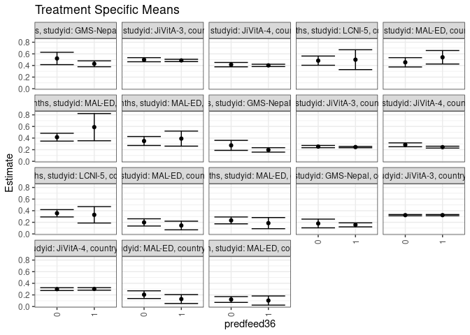

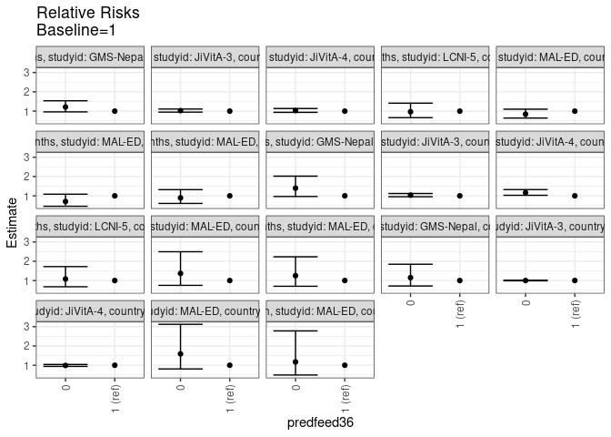

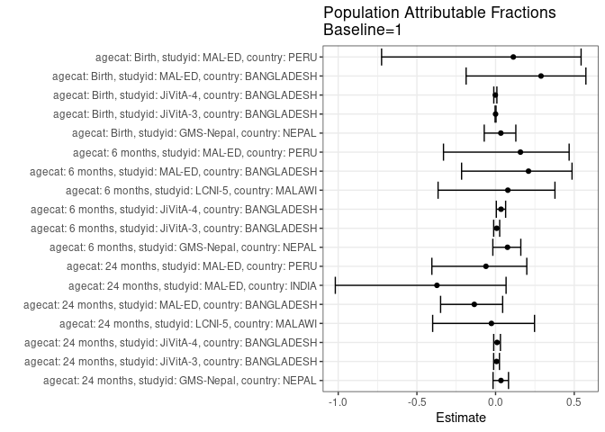

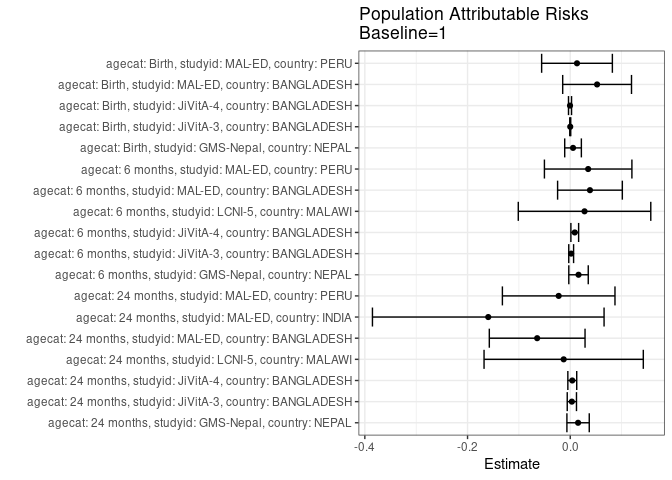

## Results Table

### Parameter: TSM

| agecat | studyid | country | intervention_level | baseline_level | estimate | ci_lower | ci_upper |
| --- | --- | --- | --- | --- | --- | --- | --- |
| Birth | GMS-Nepal | NEPAL | 1 | NA | 0.1561806 | 0.1215075 | 0.1908537 |
| Birth | GMS-Nepal | NEPAL | 0 | NA | 0.1797462 | 0.1047643 | 0.2547280 |
| Birth | JiVitA-3 | BANGLADESH | 1 | NA | 0.3234960 | 0.3131159 | 0.3338761 |
| Birth | JiVitA-3 | BANGLADESH | 0 | NA | 0.3233547 | 0.3124859 | 0.3342235 |
| Birth | JiVitA-4 | BANGLADESH | 1 | NA | 0.3027913 | 0.2807278 | 0.3248549 |
| Birth | JiVitA-4 | BANGLADESH | 0 | NA | 0.2996112 | 0.2751715 | 0.3240509 |
| Birth | MAL-ED | BANGLADESH | 1 | NA | 0.1287224 | 0.0522089 | 0.2052359 |
| Birth | MAL-ED | BANGLADESH | 0 | NA | 0.2045466 | 0.1386303 | 0.2704629 |
| Birth | MAL-ED | PERU | 1 | NA | 0.1034483 | 0.0248959 | 0.1820007 |
| Birth | MAL-ED | PERU | 0 | NA | 0.1212121 | 0.0713010 | 0.1711232 |
| 6 months | GMS-Nepal | NEPAL | 1 | NA | 0.1964185 | 0.1583790 | 0.2344580 |
| 6 months | GMS-Nepal | NEPAL | 0 | NA | 0.2744213 | 0.1882594 | 0.3605832 |
| 6 months | JiVitA-3 | BANGLADESH | 1 | NA | 0.2454075 | 0.2339152 | 0.2568998 |
| 6 months | JiVitA-3 | BANGLADESH | 0 | NA | 0.2537022 | 0.2344767 | 0.2729277 |
| 6 months | JiVitA-4 | BANGLADESH | 1 | NA | 0.2437923 | 0.2278592 | 0.2597254 |
| 6 months | JiVitA-4 | BANGLADESH | 0 | NA | 0.2845173 | 0.2512167 | 0.3178178 |
| 6 months | LCNI-5 | MALAWI | 1 | NA | 0.3288145 | 0.1874296 | 0.4701993 |
| 6 months | LCNI-5 | MALAWI | 0 | NA | 0.3553239 | 0.2925976 | 0.4180501 |
| 6 months | MAL-ED | BANGLADESH | 1 | NA | 0.1449549 | 0.0708050 | 0.2191047 |
| 6 months | MAL-ED | BANGLADESH | 0 | NA | 0.1982862 | 0.1361477 | 0.2604248 |
| 6 months | MAL-ED | PERU | 1 | NA | 0.1857207 | 0.0898812 | 0.2815603 |
| 6 months | MAL-ED | PERU | 0 | NA | 0.2326111 | 0.1735919 | 0.2916303 |
| 24 months | GMS-Nepal | NEPAL | 1 | NA | 0.4287022 | 0.3778332 | 0.4795711 |
| 24 months | GMS-Nepal | NEPAL | 0 | NA | 0.5207312 | 0.4143552 | 0.6271071 |
| 24 months | JiVitA-3 | BANGLADESH | 1 | NA | 0.4864901 | 0.4664206 | 0.5065597 |
| 24 months | JiVitA-3 | BANGLADESH | 0 | NA | 0.4989021 | 0.4635172 | 0.5342869 |
| 24 months | JiVitA-4 | BANGLADESH | 1 | NA | 0.4013353 | 0.3812012 | 0.4214693 |
| 24 months | JiVitA-4 | BANGLADESH | 0 | NA | 0.4141519 | 0.3767490 | 0.4515549 |
| 24 months | LCNI-5 | MALAWI | 1 | NA | 0.4995753 | 0.3288580 | 0.6702926 |
| 24 months | LCNI-5 | MALAWI | 0 | NA | 0.4829514 | 0.4038713 | 0.5620315 |
| 24 months | MAL-ED | BANGLADESH | 1 | NA | 0.5408252 | 0.4248812 | 0.6567692 |
| 24 months | MAL-ED | BANGLADESH | 0 | NA | 0.4543227 | 0.3743292 | 0.5343161 |
| 24 months | MAL-ED | INDIA | 1 | NA | 0.5882353 | 0.3537610 | 0.8227096 |
| 24 months | MAL-ED | INDIA | 0 | NA | 0.4154589 | 0.3481758 | 0.4827420 |
| 24 months | MAL-ED | PERU | 1 | NA | 0.3906876 | 0.2611467 | 0.5202284 |
| 24 months | MAL-ED | PERU | 0 | NA | 0.3496109 | 0.2723756 | 0.4268461 |

### Parameter: E(Y)

| agecat | studyid | country | intervention_level | baseline_level | estimate | ci_lower | ci_upper |
| --- | --- | --- | --- | --- | --- | --- | --- |
| Birth | GMS-Nepal | NEPAL | NA | NA | 0.1615970 | 0.1301114 | 0.1930825 |
| Birth | JiVitA-3 | BANGLADESH | NA | NA | 0.3234716 | 0.3131402 | 0.3338029 |
| Birth | JiVitA-4 | BANGLADESH | NA | NA | 0.3023441 | 0.2806174 | 0.3240708 |
| Birth | MAL-ED | BANGLADESH | NA | NA | 0.1809955 | 0.1301194 | 0.2318716 |
| Birth | MAL-ED | PERU | NA | NA | 0.1165919 | 0.0743750 | 0.1588088 |
| 6 months | GMS-Nepal | NEPAL | NA | NA | 0.2125237 | 0.1775632 | 0.2474842 |
| 6 months | JiVitA-3 | BANGLADESH | NA | NA | 0.2471936 | 0.2366536 | 0.2577336 |
| 6 months | JiVitA-4 | BANGLADESH | NA | NA | 0.2525687 | 0.2374550 | 0.2676823 |
| 6 months | LCNI-5 | MALAWI | NA | NA | 0.3566176 | 0.2995882 | 0.4136471 |
| 6 months | MAL-ED | BANGLADESH | NA | NA | 0.1833333 | 0.1342773 | 0.2323893 |
| 6 months | MAL-ED | PERU | NA | NA | 0.2205882 | 0.1712211 | 0.2699554 |
| 24 months | GMS-Nepal | NEPAL | NA | NA | 0.4439462 | 0.3977834 | 0.4901089 |
| 24 months | JiVitA-3 | BANGLADESH | NA | NA | 0.4896170 | 0.4715168 | 0.5077172 |
| 24 months | JiVitA-4 | BANGLADESH | NA | NA | 0.4052853 | 0.3865623 | 0.4240082 |
| 24 months | LCNI-5 | MALAWI | NA | NA | 0.4867725 | 0.4153250 | 0.5582200 |
| 24 months | MAL-ED | BANGLADESH | NA | NA | 0.4764151 | 0.4090254 | 0.5438047 |
| 24 months | MAL-ED | INDIA | NA | NA | 0.4285714 | 0.3636201 | 0.4935228 |
| 24 months | MAL-ED | PERU | NA | NA | 0.3681592 | 0.3013164 | 0.4350020 |

### Parameter: RR

| agecat | studyid | country | intervention_level | baseline_level | estimate | ci_lower | ci_upper |
| --- | --- | --- | --- | --- | --- | --- | --- |
| Birth | GMS-Nepal | NEPAL | 1 | 1 | 1.0000000 | 1.0000000 | 1.000000 |
| Birth | GMS-Nepal | NEPAL | 0 | 1 | 1.1508866 | 0.7177549 | 1.845393 |
| Birth | JiVitA-3 | BANGLADESH | 1 | 1 | 1.0000000 | 1.0000000 | 1.000000 |
| Birth | JiVitA-3 | BANGLADESH | 0 | 1 | 0.9995632 | 0.9861752 | 1.013133 |
| Birth | JiVitA-4 | BANGLADESH | 1 | 1 | 1.0000000 | 1.0000000 | 1.000000 |
| Birth | JiVitA-4 | BANGLADESH | 0 | 1 | 0.9894974 | 0.9405293 | 1.041015 |
| Birth | MAL-ED | BANGLADESH | 1 | 1 | 1.0000000 | 1.0000000 | 1.000000 |
| Birth | MAL-ED | BANGLADESH | 0 | 1 | 1.5890520 | 0.8092951 | 3.120105 |
| Birth | MAL-ED | PERU | 1 | 1 | 1.0000000 | 1.0000000 | 1.000000 |
| Birth | MAL-ED | PERU | 0 | 1 | 1.1717172 | 0.4939463 | 2.779495 |
| 6 months | GMS-Nepal | NEPAL | 1 | 1 | 1.0000000 | 1.0000000 | 1.000000 |
| 6 months | GMS-Nepal | NEPAL | 0 | 1 | 1.3971255 | 0.9656914 | 2.021308 |
| 6 months | JiVitA-3 | BANGLADESH | 1 | 1 | 1.0000000 | 1.0000000 | 1.000000 |
| 6 months | JiVitA-3 | BANGLADESH | 0 | 1 | 1.0337997 | 0.9525837 | 1.121940 |
| 6 months | JiVitA-4 | BANGLADESH | 1 | 1 | 1.0000000 | 1.0000000 | 1.000000 |
| 6 months | JiVitA-4 | BANGLADESH | 0 | 1 | 1.1670478 | 1.0283769 | 1.324418 |
| 6 months | LCNI-5 | MALAWI | 1 | 1 | 1.0000000 | 1.0000000 | 1.000000 |
| 6 months | LCNI-5 | MALAWI | 0 | 1 | 1.0806212 | 0.6783334 | 1.721487 |
| 6 months | MAL-ED | BANGLADESH | 1 | 1 | 1.0000000 | 1.0000000 | 1.000000 |
| 6 months | MAL-ED | BANGLADESH | 0 | 1 | 1.3679171 | 0.7503765 | 2.493678 |
| 6 months | MAL-ED | PERU | 1 | 1 | 1.0000000 | 1.0000000 | 1.000000 |
| 6 months | MAL-ED | PERU | 0 | 1 | 1.2524777 | 0.7032923 | 2.230510 |
| 24 months | GMS-Nepal | NEPAL | 1 | 1 | 1.0000000 | 1.0000000 | 1.000000 |
| 24 months | GMS-Nepal | NEPAL | 0 | 1 | 1.2146689 | 0.9608922 | 1.535469 |
| 24 months | JiVitA-3 | BANGLADESH | 1 | 1 | 1.0000000 | 1.0000000 | 1.000000 |
| 24 months | JiVitA-3 | BANGLADESH | 0 | 1 | 1.0255132 | 0.9478854 | 1.109498 |
| 24 months | JiVitA-4 | BANGLADESH | 1 | 1 | 1.0000000 | 1.0000000 | 1.000000 |
| 24 months | JiVitA-4 | BANGLADESH | 0 | 1 | 1.0319350 | 0.9377053 | 1.135634 |
| 24 months | LCNI-5 | MALAWI | 1 | 1 | 1.0000000 | 1.0000000 | 1.000000 |
| 24 months | LCNI-5 | MALAWI | 0 | 1 | 0.9667239 | 0.6615935 | 1.412582 |
| 24 months | MAL-ED | BANGLADESH | 1 | 1 | 1.0000000 | 1.0000000 | 1.000000 |
| 24 months | MAL-ED | BANGLADESH | 0 | 1 | 0.8400545 | 0.6412673 | 1.100464 |
| 24 months | MAL-ED | INDIA | 1 | 1 | 1.0000000 | 1.0000000 | 1.000000 |
| 24 months | MAL-ED | INDIA | 0 | 1 | 0.7062802 | 0.4593272 | 1.086005 |
| 24 months | MAL-ED | PERU | 1 | 1 | 1.0000000 | 1.0000000 | 1.000000 |
| 24 months | MAL-ED | PERU | 0 | 1 | 0.8948605 | 0.6063107 | 1.320734 |

### Parameter: PAR

| agecat | studyid | country | intervention_level | baseline_level | estimate | ci_lower | ci_upper |
| --- | --- | --- | --- | --- | --- | --- | --- |
| Birth | GMS-Nepal | NEPAL | 1 | NA | 0.0054164 | -0.0107992 | 0.0216319 |
| Birth | JiVitA-3 | BANGLADESH | 1 | NA | -0.0000244 | -0.0009801 | 0.0009313 |
| Birth | JiVitA-4 | BANGLADESH | 1 | NA | -0.0004473 | -0.0034157 | 0.0025211 |
| Birth | MAL-ED | BANGLADESH | 1 | NA | 0.0522731 | -0.0147229 | 0.1192691 |
| Birth | MAL-ED | PERU | 1 | NA | 0.0131437 | -0.0557257 | 0.0820130 |
| 6 months | GMS-Nepal | NEPAL | 1 | NA | 0.0161052 | -0.0028373 | 0.0350478 |
| 6 months | JiVitA-3 | BANGLADESH | 1 | NA | 0.0017861 | -0.0029241 | 0.0064964 |
| 6 months | JiVitA-4 | BANGLADESH | 1 | NA | 0.0087764 | 0.0012430 | 0.0163098 |
| 6 months | LCNI-5 | MALAWI | 1 | NA | 0.0278032 | -0.1011923 | 0.1567987 |
| 6 months | MAL-ED | BANGLADESH | 1 | NA | 0.0383785 | -0.0246434 | 0.1014004 |
| 6 months | MAL-ED | PERU | 1 | NA | 0.0348675 | -0.0503094 | 0.1200443 |
| 24 months | GMS-Nepal | NEPAL | 1 | NA | 0.0152440 | -0.0065149 | 0.0370030 |
| 24 months | JiVitA-3 | BANGLADESH | 1 | NA | 0.0031268 | -0.0058775 | 0.0121312 |
| 24 months | JiVitA-4 | BANGLADESH | 1 | NA | 0.0039500 | -0.0046881 | 0.0125880 |
| 24 months | LCNI-5 | MALAWI | 1 | NA | -0.0128028 | -0.1678542 | 0.1422485 |
| 24 months | MAL-ED | BANGLADESH | 1 | NA | -0.0644101 | -0.1576141 | 0.0287939 |
| 24 months | MAL-ED | INDIA | 1 | NA | -0.1596639 | -0.3851677 | 0.0658400 |
| 24 months | MAL-ED | PERU | 1 | NA | -0.0225284 | -0.1321395 | 0.0870828 |

### Parameter: PAF

| agecat | studyid | country | intervention_level | baseline_level | estimate | ci_lower | ci_upper |
| --- | --- | --- | --- | --- | --- | --- | --- |
| Birth | GMS-Nepal | NEPAL | 1 | NA | 0.0335177 | -0.0720886 | 0.1287212 |
| Birth | JiVitA-3 | BANGLADESH | 1 | NA | -0.0000754 | -0.0030342 | 0.0028746 |
| Birth | JiVitA-4 | BANGLADESH | 1 | NA | -0.0014793 | -0.0113412 | 0.0082864 |
| Birth | MAL-ED | BANGLADESH | 1 | NA | 0.2888088 | -0.1872501 | 0.5739794 |
| Birth | MAL-ED | PERU | 1 | NA | 0.1127321 | -0.7244540 | 0.5434820 |
| 6 months | GMS-Nepal | NEPAL | 1 | NA | 0.0757808 | -0.0173598 | 0.1603942 |
| 6 months | JiVitA-3 | BANGLADESH | 1 | NA | 0.0072256 | -0.0120120 | 0.0260975 |
| 6 months | JiVitA-4 | BANGLADESH | 1 | NA | 0.0347485 | 0.0046767 | 0.0639117 |
| 6 months | LCNI-5 | MALAWI | 1 | NA | 0.0779636 | -0.3654128 | 0.3773669 |
| 6 months | MAL-ED | BANGLADESH | 1 | NA | 0.2093372 | -0.2159828 | 0.4858910 |
| 6 months | MAL-ED | PERU | 1 | NA | 0.1580660 | -0.3310476 | 0.4674473 |
| 24 months | GMS-Nepal | NEPAL | 1 | NA | 0.0343376 | -0.0160455 | 0.0822223 |
| 24 months | JiVitA-3 | BANGLADESH | 1 | NA | 0.0063863 | -0.0121728 | 0.0246051 |
| 24 months | JiVitA-4 | BANGLADESH | 1 | NA | 0.0097462 | -0.0117751 | 0.0308097 |
| 24 months | LCNI-5 | MALAWI | 1 | NA | -0.0263014 | -0.3998300 | 0.2475553 |
| 24 months | MAL-ED | BANGLADESH | 1 | NA | -0.1351975 | -0.3494242 | 0.0450199 |
| 24 months | MAL-ED | INDIA | 1 | NA | -0.3725490 | -1.0185025 | 0.0666889 |
| 24 months | MAL-ED | PERU | 1 | NA | -0.0611919 | -0.4048557 | 0.1984029 |